# CSC 180 - Project One

### Contributors: *Anish Chouhan, Austin Melendez, Daniel Nishi*

### Useful Functions

```python
# Written by Dr. Haiquan Chen

from collections.abc import Sequence
from sklearn import preprocessing
import matplotlib.pyplot as plt
import numpy as np
import pandas as pd


# Encode text values to dummy variables(i.e. [1,0,0],[0,1,0],[0,0,1] for red,green,blue)
def encode_text_dummy(df, name):
    dummies = pd.get_dummies(df[name])
    for x in dummies.columns:
        dummy_name = "{}-{}".format(name, x)
        df[dummy_name] = dummies[x]
    df.drop(name, axis=1, inplace=True)


# Encode text values to indexes(i.e. [1],[2],[3] for red,green,blue).
def encode_text_index(df, name):
    le = preprocessing.LabelEncoder()
    df[name] = le.fit_transform(df[name])
    return le.classes_


# Encode a numeric column as zscores
def encode_numeric_zscore(df, name, mean=None, sd=None):
    if mean is None:
        mean = df[name].mean()

    if sd is None:
        sd = df[name].std()

    df[name] = (df[name] - mean) / sd


# Convert all missing values in the specified column to the median
def missing_median(df, name):
    med = df[name].median()
    df[name] = df[name].fillna(med)


# Convert all missing values in the specified column to the default
def missing_default(df, name, default_value):
    df[name] = df[name].fillna(default_value)


# Convert a Pandas dataframe to the x,y inputs that TensorFlow needs
def to_xy(df, target):
    result = []
    for x in df.columns:
        if x != target:
            result.append(x)
    # find out the type of the target column.
    target_type = df[target].dtypes
    target_type = target_type[0] if isinstance(target_type, Sequence) else target_type
    # Encode to int for classification, float otherwise. TensorFlow likes 32 bits.
    if target_type in (np.int64, np.int32):
        # Classification
        dummies = pd.get_dummies(df[target])
        return df[result].values.astype(np.float32), dummies.values.astype(np.float32)
    else:
        # Regression
        return df[result].values.astype(np.float32), df[target].values.astype(np.float32)

# Nicely formatted time string
def hms_string(sec_elapsed):
    h = int(sec_elapsed / (60 * 60))
    m = int((sec_elapsed % (60 * 60)) / 60)
    s = sec_elapsed % 60
    return "{}:{:>02}:{:>05.2f}".format(h, m, s)


# Regression chart.
def chart_regression(pred,y,sort=True):
    t = pd.DataFrame({'pred' : pred, 'y' : y})
    if sort:
        t.sort_values(by=['y'],inplace=True)
    a = plt.plot(t['y'].tolist(),label='expected')
    b = plt.plot(t['pred'].tolist(),label='prediction')
    plt.ylabel('output')
    plt.legend()
    plt.show()

# Remove all rows where the specified column is +/- sd standard deviations
def remove_outliers(df, name, sd):
    drop_rows = df.index[(np.abs(df[name] - df[name].mean()) >= (sd * df[name].std()))]
    df.drop(drop_rows, axis=0, inplace=True)


# Encode a column to a range between normalized_low and normalized_high.
def encode_numeric_range(df, name, normalized_low=0, normalized_high=1,
                         data_low=None, data_high=None):
    if data_low is None:
        data_low = min(df[name])
        data_high = max(df[name])

    df[name] = ((df[name] - data_low) / (data_high - data_low)) * (normalized_high - normalized_low) + normalized_low
```

## Preprocessing

### File Processing

Reading the business data from Yelp's json file and filtering out businesses with less then 20 reviews

```python
import pandas as pd
from google.colab import drive
from google.colab import drive
drive.mount('/content/drive')
import os
os.chdir('/content/drive/My Drive/180 project 1')

# Reads the first million rows of the json file
df_business = pd.read_json('./data/yelp_academic_dataset_business.json', lines=True, nrows = 1000000)


# Removing all businesses with less than 20 reviews
df_business = df_business[df_business['review_count'] >= 20]

print(df_business.shape)
df_business.head()
```

[output not shown]

Reading the review data from Yelp's json file.

```python
import json
import pandas as pd

import os
os.chdir('/content/drive/My Drive/180 project 1')
df_review = pd.read_json('./data/yelp_review.json', lines=True, nrows = 1000000)

print(df_review.shape)
df_review.head()
```

```
(1000000, 9)
```

|  | review_id | user_id | business_id | stars | useful | funny | cool | text | date |
| --- | --- | --- | --- | --- | --- | --- | --- | --- | --- |
| 0 | KU_O5udG6zpxOg-VcAEodg | mh_-eMZ6K5RLWhZyISBhwA | XQfwVwDr-v0ZS3_CbbE5Xw | 3 | 0 | 0 | 0 | If you decide to eat here, just be aware it is... | 2018-07-07 22:09:11 |
| 1 | BiTunyQ73aT9WBnpR9DZGw | OyoGAe7OKpv6SyGZT5g77Q | 7ATYjTIgM3jUlt4UM3IypQ | 5 | 1 | 0 | 1 | I've taken a lot of spin classes over the year... | 2012-01-03 15:28:18 |
| 2 | saUsX_uimxRlCVr67Z4Jig | 8g_iMtfSiwikVnbP2etR0A | YjUWPpI6HXG530lwP-fb2A | 3 | 0 | 0 | 0 | Family diner. Had the buffet. Eclectic assortm... | 2014-02-05 20:30:30 |
| 3 | AqPFMleE6RsU23_auESxiA | _7bHUi9Uuf5__HHc_Q8guQ | kxX2SOes4o-D3ZQBkiMRfA | 5 | 1 | 0 | 1 | Wow! Yummy, different, delicious. Our favo... | 2015-01-04 00:01:03 |
| 4 | Sx8TMOWLNuJBWer-0pcmoA | bcjbaE6dDog4jkNY91ncLQ | e4Vwtrqf-wpJfwesgvdgxQ | 4 | 1 | 0 | 1 | Cute interior and owner (?) gave us tour of up... | 2017-01-14 20:54:15 |

Grouping unique businesses together with all of their associated reviews

```python
df_review_agg = df_review.groupby('business_id')['text'].sum()
funny = df_review.groupby('business_id')['funny'].mean()
useful = df_review.groupby('business_id')['useful'].mean()
df_ready_to_be_sent_to_sklearn = pd.DataFrame({'business_id': df_review_agg.index,'all_reviews': df_review_agg.values,'useful': useful.values ,'funny': funny.values})
df_review_merged = pd.merge(df_ready_to_be_sent_to_sklearn, df_business, on='business_id')
print(df_review_merged.shape)
df_review_merged.head()
```

```
(11927, 17)
```

|  | business_id | all_reviews | useful | funny | name | address | city | state | postal_code | latitude | longitude | stars | review_count | is_open | attributes | categories | hours |
| --- | --- | --- | --- | --- | --- | --- | --- | --- | --- | --- | --- | --- | --- | --- | --- | --- | --- |
| 0 | --ZVrH2X2QXBFdCilbirsw | This place is sadly perm closed. I was hoping ... | 1.333333 | 0.611111 | Chris's Sandwich Shop | 1531 W Wynnewood Rd | Ardmore | PA | 19003 | 39.997299 | -75.292207 | 4.5 | 32 | 0 | {'GoodForKids': 'True', 'RestaurantsAttire': '... | American (Traditional), Restaurants, Pizza, Sa... | {'Monday': '11:0-21:0', 'Tuesday': '11:0-21:0'... |
| 1 | --sXnWH9Xm6_NvIjyuA99w | Ich war das erste mal in Philadelphia und ich ... | 0.200000 | 0.000000 | Philadelphia |  | Philadelphia | PA |  | 39.952584 | -75.165222 | 4.0 | 29 | 1 | {'GoodForKids': 'True'} | Public Services & Government, Local Flavor | None |
| 2 | -02xFuruu85XmDn2xiynJw | Dr. Curtis Dechant has an excellent chair-side... | 0.743802 | 0.066116 | Family Vision Center | 7475 E Tanque Verde Rd | Tucson | AZ | 85715 | 32.251039 | -110.833173 | 4.5 | 109 | 1 | {'ByAppointmentOnly': 'True', 'BusinessParking... | Shopping, Ophthalmologists, Optometrists, Doct... | {'Monday': '0:0-0:0', 'Tuesday': '8:30-17:30',... |
| 3 | -06OYKiIzxsdymBMDAKZug | Had catalytic converters replaced on our Subur... | 0.666667 | 0.416667 | Washoe Metal Fabricating | 905 Bergin Way | Sparks | NV | 89431 | 39.525558 | -119.739221 | 4.5 | 34 | 1 | {'BusinessAcceptsCreditCards': 'True', 'ByAppo... | RV Dealers, Home Services, Shopping, Tires, Au... | {'Monday': '7:30-17:30', 'Tuesday': '7:30-17:3... |
| 4 | -06ngMH_Ejkm_6HQBYxB7g | I have an old main line that really should be ... | 0.000000 | 0.000000 | Stewart's De Rooting & Plumbing | 415 E Montecito St | Santa Barbara | CA | 93101 | 34.419838 | -119.688029 | 4.0 | 25 | 1 | {'BusinessAcceptsCreditCards': 'True', 'ByAppo... | Plumbing, Home Services | {'Monday': '0:0-0:0', 'Tuesday': '0:0-0:0', 'W... |

Normalizing review count, funny, and useful

```python
encode_numeric_range(df_review_merged,'review_count')
encode_numeric_range(df_review_merged,'funny')
encode_numeric_range(df_review_merged,'useful')
print(df_review_merged.shape)
df_review_merged.head()
```

```
(11927, 17)
```

|  | business_id | all_reviews | useful | funny | name | address | city | state | postal_code | latitude | longitude | stars | review_count | is_open | attributes | categories | hours |
| --- | --- | --- | --- | --- | --- | --- | --- | --- | --- | --- | --- | --- | --- | --- | --- | --- | --- |
| 0 | --ZVrH2X2QXBFdCilbirsw | This place is sadly perm closed. I was hoping ... | 0.017608 | 0.027681 | Chris's Sandwich Shop | 1531 W Wynnewood Rd | Ardmore | PA | 19003 | 39.997299 | -75.292207 | 4.5 | 0.002647 | 0 | {'GoodForKids': 'True', 'RestaurantsAttire': '... | American (Traditional), Restaurants, Pizza, Sa... | {'Monday': '11:0-21:0', 'Tuesday': '11:0-21:0'... |
| 1 | --sXnWH9Xm6_NvIjyuA99w | Ich war das erste mal in Philadelphia und ich ... | 0.002641 | 0.000000 | Philadelphia |  | Philadelphia | PA |  | 39.952584 | -75.165222 | 4.0 | 0.001985 | 1 | {'GoodForKids': 'True'} | Public Services & Government, Local Flavor | None |
| 2 | -02xFuruu85XmDn2xiynJw | Dr. Curtis Dechant has an excellent chair-side... | 0.009823 | 0.002995 | Family Vision Center | 7475 E Tanque Verde Rd | Tucson | AZ | 85715 | 32.251039 | -110.833173 | 4.5 | 0.019629 | 1 | {'ByAppointmentOnly': 'True', 'BusinessParking... | Shopping, Ophthalmologists, Optometrists, Doct... | {'Monday': '0:0-0:0', 'Tuesday': '8:30-17:30',... |
| 3 | -06OYKiIzxsdymBMDAKZug | Had catalytic converters replaced on our Subur... | 0.008804 | 0.018873 | Washoe Metal Fabricating | 905 Bergin Way | Sparks | NV | 89431 | 39.525558 | -119.739221 | 4.5 | 0.003088 | 1 | {'BusinessAcceptsCreditCards': 'True', 'ByAppo... | RV Dealers, Home Services, Shopping, Tires, Au... | {'Monday': '7:30-17:30', 'Tuesday': '7:30-17:3... |
| 4 | -06ngMH_Ejkm_6HQBYxB7g | I have an old main line that really should be ... | 0.000000 | 0.000000 | Stewart's De Rooting & Plumbing | 415 E Montecito St | Santa Barbara | CA | 93101 | 34.419838 | -119.688029 | 4.0 | 0.001103 | 1 | {'BusinessAcceptsCreditCards': 'True', 'ByAppo... | Plumbing, Home Services | {'Monday': '0:0-0:0', 'Tuesday': '0:0-0:0', 'W... |

### TF-IDF

Creating several TF-IDF matrices with a varying amount of features

```python
from sklearn.feature_extraction.text import TfidfVectorizer
v_500 = TfidfVectorizer( max_features= 500,stop_words= 'english', min_df=1)
v_1000 = TfidfVectorizer( max_features= 1000,stop_words= 'english', min_df=1)
v_1500 = TfidfVectorizer( max_features= 1500,stop_words= 'english', min_df=1)

matrix_500 = v_500.fit_transform(df_review_merged['all_reviews'])
matrix_1000 = v_1000.fit_transform(df_review_merged['all_reviews'])
matrix_1500 = v_1500.fit_transform(df_review_merged['all_reviews'])
print("done")
```

```
done
```

Testing TF-IDF with 500 featured words

```python
from sklearn.model_selection import train_test_split

featured_names = v_500.get_feature_names_out()

x_data = matrix_500.toarray()
print(x_data)
print(featured_names)

x = x_data
y = df_review_merged['stars']

x_train, x_test, y_train, y_test = train_test_split(x, y, test_size=0.20, random_state=42)
```

```
[[0.         0.         0.         ... 0.01580098 0.         0.        ]
 [0.         0.         0.         ... 0.         0.         0.        ]
 [0.0053805  0.03197492 0.042989   ... 0.03536421 0.00676511 0.        ]
 ...
 [0.         0.         0.         ... 0.         0.         0.        ]
 [0.03936097 0.         0.         ... 0.02069652 0.         0.03580244]
 [0.         0.         0.         ... 0.04504372 0.         0.        ]]
['10' '15' '20' '30' '50' 'able' 'absolutely' 'actually' 'add' 'ago'
 'amazing' 'ambiance' 'appetizer' 'area' 'arrived' 'ask' 'asked' 'ate'
 'atmosphere' 'attentive' 'authentic' 'available' 'average' 'away'
 'awesome' 'bacon' 'bad' 'bar' 'bartender' 'bbq' 'beans' 'beautiful'
 'beef' 'beer' 'beers' 'believe' 'best' 'better' 'big' 'birthday' 'bit'
 'bite' 'bowl' 'boyfriend' 'bread' 'breakfast' 'bring' 'brought' 'brunch'
 'burger' 'burgers' 'business' 'busy' 'butter' 'buy' 'cake' 'called'
 'came' 'car' 'care' 'change' 'charge' 'cheap' 'check' 'cheese' 'chef'
 'chicken' 'chips' 'chocolate' 'choice' 'choose' 'city' 'clean' 'close'
 'coffee' 'cold' 'come' 'comes' 'comfortable' 'coming' 'company'
 'completely' 'cooked' 'cool' 'couldn' 'counter' 'couple' 'course' 'crab'
 'cream' 'crispy' 'customer' 'customers' 'cut' 'cute' 'day' 'days' 'deal'
 'decent' 'decided' 'decor' 'definitely' 'delicious' 'delivery' 'dessert'
 'did' 'didn' 'different' 'dining' 'dinner' 'disappointed' 'dish' 'dishes'
 'does' 'doesn' 'dog' 'doing' 'don' 'door' 'drink' 'drinks' 'drive' 'dry'
 'early' 'easy' 'eat' 'eaten' 'eating' 'egg' 'eggs' 'employees' 'end'
 'ended' 'enjoy' 'enjoyed' 'entire' 'especially' 'evening' 'excellent'
 'expect' 'expected' 'expensive' 'experience' 'extra' 'extremely' 'fact'
 'family' 'fan' 'fantastic' 'far' 'fast' 'favorite' 'feel' 'felt'
 'finally' 'fine' 'fish' 'flavor' 'flavorful' 'flavors' 'floor' 'food'
 'free' 'french' 'fresh' 'friday' 'fried' 'friend' 'friendly' 'friends'
 'fries' 'fun' 'garlic' 'gave' 'gets' 'getting' 'given' 'glad' 'glass'
 'going' 'good' 'got' 'great' 'green' 'grilled' 'group' 'guess' 'guy'
 'guys' 'hair' 'half' 'hands' 'happy' 'hard' 'haven' 'having' 'heard'
 'help' 'helpful' 'high' 'highly' 'hit' 'home' 'horrible' 'hot' 'hotel'
 'hour' 'hours' 'house' 'huge' 'husband' 'ice' 'immediately' 'impressed'
 'ingredients' 'inside' 'instead' 'isn' 'italian' 'items' 'job' 'just'
 'kept' 'kids' 'kind' 'kitchen' 'knew' 'know' 'large' 'late' 'later'
 'leave' 'left' 'let' 'life' 'light' 'like' 'liked' 'line' 'list'
 'literally' 'little' 'live' 'll' 'local' 'location' 'long' 'look'
 'looked' 'looking' 'looks' 'lot' 'lots' 'love' 'loved' 'lunch' 'mac'
 'main' 'make' 'makes' 'making' 'man' 'manager' 'maybe' 'meal' 'meals'
 'meat' 'menu' 'mexican' 'mind' 'minutes' 'money' 'months' 'morning'
```

[output cut: 13 more lines]

```
 'say' 'seafood' 'seated' 'seating' 'second' 'seen' 'selection' 'serve'
 'served' 'server' 'servers' 'service' 'set' 'shop' 'short' 'shrimp'
 'simple' 'sit' 'sitting' 'size' 'slow' 'small' 'soon' 'soup' 'space'
 'special' 'spicy' 'spot' 'st' 'staff' 'star' 'stars' 'start' 'started'
 'stay' 'steak' 'stop' 'stopped' 'store' 'street' 'stuff' 'style' 'sunday'
 'super' 'sure' 'surprised' 'sushi' 'sweet' 'table' 'tables' 'taco'
 'tacos' 'taking' 'taste' 'tasted' 'tasty' 'tea' 'tell' 'terrible' 'thai'
 'thank' 'thanks' 'thing' 'things' 'think' 'thought' 'time' 'times' 'tip'
 'toast' 'today' 'told' 'took' 'totally' 'tour' 'town' 'tried' 'trip'
 'try' 'trying' 'twice' 'unfortunately' 'unique' 'use' 'used' 'usually'
 'variety' 've' 'visit' 'wait' 'waited' 'waiter' 'waiting' 'waitress'
 'walk' 'walked' 'walking' 'want' 'wanted' 'warm' 'wasn' 'water' 'way'
 'week' 'weekend' 'went' 'weren' 'white' 'wife' 'wine' 'wings' 'wish'
 'won' 'wonderful' 'work' 'working' 'worst' 'worth' 'wouldn' 'wrong'
 'year' 'years' 'yelp' 'yes' 'yummy']
```

```
75/75 - 1s - loss: 4.0335 - val_loss: 1.0342 - 615ms/epoch - 8ms/step
75/75 - 0s - loss: 0.8223 - val_loss: 0.5866 - 149ms/epoch - 2ms/step
75/75 - 0s - loss: 0.4567 - val_loss: 0.3588 - 162ms/epoch - 2ms/step
75/75 - 0s - loss: 0.3183 - val_loss: 0.3036 - 155ms/epoch - 2ms/step
75/75 - 0s - loss: 0.2721 - val_loss: 0.2723 - 146ms/epoch - 2ms/step
75/75 - 0s - loss: 0.2420 - val_loss: 0.2473 - 157ms/epoch - 2ms/step
75/75 - 0s - loss: 0.2183 - val_loss: 0.2300 - 156ms/epoch - 2ms/step
75/75 - 0s - loss: 0.2000 - val_loss: 0.2159 - 153ms/epoch - 2ms/step
75/75 - 0s - loss: 0.1857 - val_loss: 0.2084 - 141ms/epoch - 2ms/step
75/75 - 0s - loss: 0.1769 - val_loss: 0.2038 - 153ms/epoch - 2ms/step
75/75 - 0s - loss: 0.1708 - val_loss: 0.2020 - 157ms/epoch - 2ms/step
75/75 - 0s - loss: 0.1679 - val_loss: 0.1996 - 159ms/epoch - 2ms/step
75/75 - 0s - loss: 0.1642 - val_loss: 0.1995 - 142ms/epoch - 2ms/step
75/75 - 0s - loss: 0.1622 - val_loss: 0.1986 - 157ms/epoch - 2ms/step
75/75 - 0s - loss: 0.1600 - val_loss: 0.2005 - 119ms/epoch - 2ms/step
75/75 - 0s - loss: 0.1584 - val_loss: 0.1988 - 132ms/epoch - 2ms/step
75/75 - 0s - loss: 0.1568 - val_loss: 0.1991 - 119ms/epoch - 2ms/step
75/75 - 0s - loss: 0.1575 - val_loss: 0.1978 - 165ms/epoch - 2ms/step
75/75 - 0s - loss: 0.1546 - val_loss: 0.2012 - 121ms/epoch - 2ms/step
Epoch 19: early stopping
Final score (RMSE): 0.4447068023941592
```

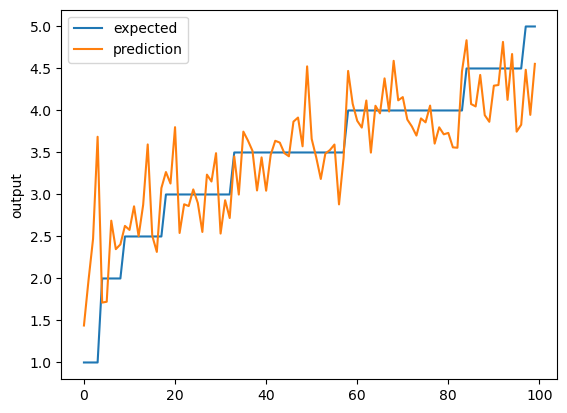

```python
from tensorflow.keras.models import Sequential
from tensorflow.keras.layers import Dense, Activation
from tensorflow.keras.callbacks import EarlyStopping, ModelCheckpoint
import pandas as pd
import io
import requests
import numpy as np
from sklearn import metrics

model = Sequential()
x_train = x_train.astype('float32')
y_train = y_train.astype('float32')

model.add(Dense(64, input_dim=x_train.shape[1], activation='relu'))
model.add(Dense(10, activation='relu'))
model.add(Dense(1))

model.compile(loss='mean_squared_error', optimizer='adam')

monitor = EarlyStopping(monitor='val_loss', min_delta=1e-3, patience=5, verbose=0, mode='auto')
checkpointer = ModelCheckpoint(filepath="./dnn/best_weights.keras", verbose=0, save_best_only=True)

model.fit(x_train,y_train,validation_data=(x_test,y_test), batch_size= 128, callbacks=[monitor,checkpointer],verbose=0,epochs=1000)
model.load_weights('./dnn/best_weights.keras')

pred = model.predict(x_test)

score_500 = np.sqrt(metrics.mean_squared_error(pred,y_test))
print("Final score (RMSE): {}".format(score_500))

chart_regression(pred.flatten()[0:100],y_test.to_numpy()[0:100], sort=True)
```

Testing TF-IDF with 1000 featured words

```python
from sklearn.model_selection import train_test_split

featured_names = v_1000.get_feature_names_out()

x_data = matrix_1000.toarray()
print(x_data)
print(featured_names)

x = x_data
y = df_review_merged['stars']

x_train, x_test, y_train, y_test = train_test_split(x, y, test_size=0.20, random_state=42)
```

```
[[0.01703163 0.         0.         ... 0.         0.04169674 0.        ]
 [0.         0.         0.         ... 0.         0.         0.        ]
 [0.         0.00297757 0.01861302 ... 0.00444197 0.         0.        ]
 ...
 [0.06741645 0.         0.         ... 0.         0.         0.        ]
 [0.         0.03405764 0.         ... 0.03048457 0.         0.03097857]
 [0.         0.         0.         ... 0.03764996 0.         0.        ]]
['00' '10' '100' '11' '12' '15' '20' '25' '30' '40' '45' '50' 'able'
 'absolutely' 'accommodating' 'actually' 'add' 'added' 'addition'
 'affordable' 'afternoon' 'ago' 'ahead' 'air' 'amazing' 'ambiance'
 'american' 'apparently' 'appetizer' 'appetizers' 'apple' 'appointment'
 'appreciate' 'area' 'aren' 'arrived' 'art' 'asian' 'ask' 'asked' 'asking'
 'ate' 'atmosphere' 'attention' 'attentive' 'attitude' 'authentic'
 'available' 'average' 'avocado' 'avoid' 'away' 'awesome' 'awful' 'bacon'
 'bad' 'bag' 'baked' 'bakery' 'bar' 'barbara' 'barely' 'bars' 'bartender'
 'bartenders' 'based' 'basic' 'basically' 'bathroom' 'bbq' 'beach' 'beans'
 'beat' 'beautiful' 'bed' 'beef' 'beer' 'beers' 'believe' 'best' 'better'
 'big' 'birthday' 'bit' 'bite' 'black' 'bland' 'blue' 'book' 'bottle'
 'bought' 'bourbon' 'bowl' 'box' 'boy' 'boyfriend' 'bread' 'breakfast'
 'bring' 'brisket' 'broth' 'brought' 'brown' 'brunch' 'buffet' 'building'
 'bun' 'bunch' 'burger' 'burgers' 'burrito' 'business' 'busy' 'butter'
 'buy' 'cafe' 'cake' 'cakes' 'called' 'came' 'car' 'card' 'care' 'case'
 'cash' 'casual' 'center' 'certainly' 'chain' 'chairs' 'chance' 'change'
 'changed' 'charge' 'charged' 'cheap' 'check' 'checked' 'checking'
 'cheese' 'chef' 'chicken' 'chili' 'chinese' 'chips' 'chocolate' 'choice'
 'choices' 'choose' 'chose' 'city' 'class' 'classic' 'clean' 'clear'
 'clearly' 'close' 'closed' 'club' 'cocktail' 'cocktails' 'coffee' 'cold'
 'color' 'combo' 'come' 'comes' 'comfortable' 'coming' 'company'
 'complaint' 'completely' 'considering' 'convenient' 'conversation' 'cook'
 'cooked' 'cool' 'corn' 'corner' 'cost' 'couldn' 'counter' 'couple'
 'course' 'covered' 'cozy' 'crab' 'craving' 'crawfish' 'crazy' 'cream'
 'creamy' 'credit' 'crispy' 'crowd' 'crowded' 'crust' 'cup' 'curry'
 'customer' 'customers' 'cut' 'cute' 'dark' 'date' 'daughter' 'day' 'days'
 'deal' 'decent' 'decided' 'decor' 'deep' 'definitely' 'delicious'
 'delivered' 'delivery' 'desk' 'despite' 'dessert' 'desserts' 'did' 'didn'
 'die' 'different' 'difficult' 'dine' 'diner' 'dining' 'dinner' 'dip'
 'dirty' 'disappoint' 'disappointed' 'disappointing' 'dish' 'dishes'
 'does' 'doesn' 'dog' 'dogs' 'doing' 'dollars' 'don' 'donuts' 'door'
 'double' 'downtown' 'dr' 'dressing' 'drink' 'drinks' 'drive' 'dry' 'duck'
 'early' 'easily' 'easy' 'eat' 'eaten' 'eating' 'efficient' 'egg' 'eggs'
```

[output cut: 77 more lines]

```
 'thought' 'time' 'times' 'tiny' 'tip' 'toast' 'today' 'tofu' 'told'
 'tomato' 'tomatoes' 'tonight' 'took' 'topped' 'toppings' 'total'
 'totally' 'touch' 'tour' 'town' 'traditional' 'treat' 'treated' 'tried'
 'trip' 'truck' 'true' 'truly' 'try' 'trying' 'tucson' 'tuna' 'turkey'
 'turn' 'turned' 'tv' 'twice' 'type' 'typical' 'understand'
 'unfortunately' 'unique' 'unless' 'update' 'use' 'used' 'using' 'usual'
 'usually' 'value' 'variety' 've' 'vegan' 'vegetables' 'vegetarian'
 'veggie' 'veggies' 'vibe' 'view' 'visit' 'visited' 'visiting' 'wait'
 'waited' 'waiter' 'waiting' 'waitress' 'walk' 'walked' 'walking' 'wall'
 'want' 'wanted' 'warm' 'wasn' 'waste' 'watch' 'watching' 'water' 'way'
 'wedding' 'week' 'weekend' 'weeks' 'weird' 'welcoming' 'went' 'weren'
 'white' 'wife' 'window' 'wine' 'wings' 'wish' 'woman' 'won' 'wonderful'
 'word' 'work' 'worked' 'working' 'works' 'world' 'worse' 'worst' 'worth'
 'wouldn' 'wow' 'write' 'wrong' 'year' 'years' 'yelp' 'yes' 'young' 'yum'
 'yummy']
```

```
75/75 - 1s - loss: 3.9643 - val_loss: 1.0764 - 759ms/epoch - 10ms/step
75/75 - 1s - loss: 0.7773 - val_loss: 0.4891 - 519ms/epoch - 7ms/step
75/75 - 0s - loss: 0.3912 - val_loss: 0.3275 - 431ms/epoch - 6ms/step
75/75 - 0s - loss: 0.2896 - val_loss: 0.2752 - 405ms/epoch - 5ms/step
75/75 - 0s - loss: 0.2433 - val_loss: 0.2459 - 455ms/epoch - 6ms/step
75/75 - 1s - loss: 0.2137 - val_loss: 0.2277 - 528ms/epoch - 7ms/step
75/75 - 1s - loss: 0.1914 - val_loss: 0.2134 - 784ms/epoch - 10ms/step
75/75 - 1s - loss: 0.1739 - val_loss: 0.2050 - 648ms/epoch - 9ms/step
75/75 - 1s - loss: 0.1608 - val_loss: 0.1990 - 554ms/epoch - 7ms/step
75/75 - 1s - loss: 0.1512 - val_loss: 0.1977 - 629ms/epoch - 8ms/step
75/75 - 1s - loss: 0.1450 - val_loss: 0.1972 - 531ms/epoch - 7ms/step
75/75 - 0s - loss: 0.1400 - val_loss: 0.1961 - 424ms/epoch - 6ms/step
75/75 - 1s - loss: 0.1361 - val_loss: 0.1973 - 521ms/epoch - 7ms/step
75/75 - 0s - loss: 0.1326 - val_loss: 0.1988 - 454ms/epoch - 6ms/step
75/75 - 1s - loss: 0.1311 - val_loss: 0.1987 - 627ms/epoch - 8ms/step
75/75 - 1s - loss: 0.1275 - val_loss: 0.1991 - 682ms/epoch - 9ms/step
75/75 - 0s - loss: 0.1254 - val_loss: 0.1983 - 420ms/epoch - 6ms/step
Epoch 17: early stopping
Final score (RMSE): 0.44283127515748644
```

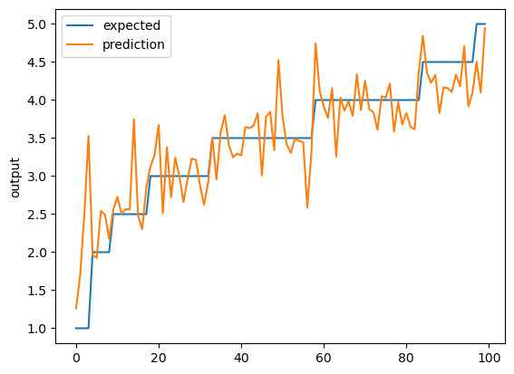

```python
from tensorflow.keras.models import Sequential
from tensorflow.keras.layers import Dense, Activation
import pandas as pd
import io
import requests
import numpy as np
from sklearn import metrics

model = Sequential()
x_train = x_train.astype('float32')
y_train = y_train.astype('float32')

model.add(Dense(64, input_dim=x_train.shape[1], activation='relu'))
model.add(Dense(10, activation='relu'))
model.add(Dense(1))

model.compile(loss='mean_squared_error', optimizer='adam')

monitor = EarlyStopping(monitor='val_loss', min_delta=1e-3, patience=5, verbose=0, mode='auto')
checkpointer = ModelCheckpoint(filepath="./dnn/best_weights.keras", verbose=0, save_best_only=True)

model.fit(x_train,y_train,validation_data=(x_test,y_test), batch_size= 128, callbacks=[monitor,checkpointer],verbose=0,epochs=1000)
model.load_weights('./dnn/best_weights.keras')

pred = model.predict(x_test)

score_1000 = np.sqrt(metrics.mean_squared_error(pred,y_test))
print("Final score (RMSE): {}".format(score_1000))

chart_regression(pred.flatten()[0:100],y_test.to_numpy()[0:100], sort=True)
```

Testing TF-IDF with 1500 featured words

```python
from sklearn.model_selection import train_test_split

featured_names = v_1500.get_feature_names_out()

x_data = matrix_1500.toarray()
print(x_data)
print(featured_names)

x = x_data
y = df_review_merged['stars']

x_train, x_test, y_train, y_test = train_test_split(x, y, test_size=0.20, random_state=42)
```

```
[[0.01607719 0.         0.         ... 0.03936009 0.         0.        ]
 [0.         0.         0.         ... 0.         0.         0.        ]
 [0.         0.00286787 0.0179273  ... 0.         0.         0.        ]
 ...
 [0.04624286 0.         0.         ... 0.         0.         0.01412062]
 [0.         0.03299562 0.         ... 0.         0.03001257 0.02396271]
 [0.         0.         0.         ... 0.         0.         0.        ]]
['00' '10' '100' ... 'yum' 'yummy' 'zero']
```

```
75/75 - 1s - loss: 3.9762 - val_loss: 1.1893 - 1s/epoch - 15ms/step
75/75 - 1s - loss: 0.8927 - val_loss: 0.6024 - 587ms/epoch - 8ms/step
75/75 - 0s - loss: 0.4677 - val_loss: 0.3753 - 490ms/epoch - 7ms/step
75/75 - 1s - loss: 0.3143 - val_loss: 0.2902 - 846ms/epoch - 11ms/step
75/75 - 1s - loss: 0.2403 - val_loss: 0.2445 - 765ms/epoch - 10ms/step
75/75 - 1s - loss: 0.1974 - val_loss: 0.2197 - 799ms/epoch - 11ms/step
75/75 - 1s - loss: 0.1725 - val_loss: 0.2052 - 721ms/epoch - 10ms/step
75/75 - 1s - loss: 0.1570 - val_loss: 0.1985 - 627ms/epoch - 8ms/step
75/75 - 1s - loss: 0.1473 - val_loss: 0.1962 - 543ms/epoch - 7ms/step
75/75 - 0s - loss: 0.1392 - val_loss: 0.1941 - 454ms/epoch - 6ms/step
75/75 - 1s - loss: 0.1341 - val_loss: 0.1930 - 919ms/epoch - 12ms/step
75/75 - 1s - loss: 0.1296 - val_loss: 0.1915 - 523ms/epoch - 7ms/step
75/75 - 0s - loss: 0.1263 - val_loss: 0.1923 - 427ms/epoch - 6ms/step
75/75 - 1s - loss: 0.1236 - val_loss: 0.1930 - 538ms/epoch - 7ms/step
75/75 - 1s - loss: 0.1206 - val_loss: 0.1924 - 784ms/epoch - 10ms/step
75/75 - 1s - loss: 0.1180 - val_loss: 0.1942 - 597ms/epoch - 8ms/step
75/75 - 1s - loss: 0.1138 - val_loss: 0.1941 - 803ms/epoch - 11ms/step
Epoch 17: early stopping
Final score (RMSE): 0.4376633116069291
```

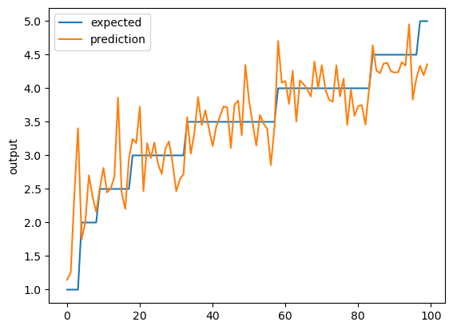

```python
from tensorflow.keras.models import Sequential
from tensorflow.keras.layers import Dense, Activation
import pandas as pd
import io
import requests
import numpy as np
from sklearn import metrics

model = Sequential()
x_train = x_train.astype('float32')
y_train = y_train.astype('float32')

model.add(Dense(64, input_dim=x_train.shape[1], activation='relu'))
model.add(Dense(10, activation='relu'))
model.add(Dense(1))

model.compile(loss='mean_squared_error', optimizer='adam')

monitor = EarlyStopping(monitor='val_loss', min_delta=1e-3, patience=5, verbose=0, mode='auto')
checkpointer = ModelCheckpoint(filepath="./dnn/best_weights.keras", verbose=0, save_best_only=True)

model.fit(x_train,y_train,validation_data=(x_test,y_test), batch_size= 128, callbacks=[monitor,checkpointer],verbose=0,epochs=1000)
model.load_weights('./dnn/best_weights.keras')

pred = model.predict(x_test)

score_1500 = np.sqrt(metrics.mean_squared_error(pred,y_test))
print("Final score (RMSE): {}".format(score_1500))

chart_regression(pred.flatten()[0:100],y_test.to_numpy()[0:100], sort=True)
```

Test Results

```python
print("Final score (RMSE) when max_feature=500:\t{}".format(score_500))
print("Final score (RMSE) when max_feature=1000:\t{}".format(score_1000))
print("Final score (RMSE) when max_feature=1500:\t{}".format(score_1500))
```

```
Final score (RMSE) when max_feature=500:	0.4447068023941592
Final score (RMSE) when max_feature=1000:	0.44283127515748644
Final score (RMSE) when max_feature=1500:	0.4376633116069291
```

```python
from sklearn.model_selection import train_test_split

featured_names = v_1000.get_feature_names_out()

x_data = matrix_1000.toarray()
print(x_data)
print(featured_names)

x = x_data
y = df_review_merged['stars']

x_train, x_test, y_train, y_test = train_test_split(x, y, test_size=0.20, random_state=42)
```

```
[[0.01703163 0.         0.         ... 0.         0.04169674 0.        ]
 [0.         0.         0.         ... 0.         0.         0.        ]
 [0.         0.00297757 0.01861302 ... 0.00444197 0.         0.        ]
 ...
 [0.06741645 0.         0.         ... 0.         0.         0.        ]
 [0.         0.03405764 0.         ... 0.03048457 0.         0.03097857]
 [0.         0.         0.         ... 0.03764996 0.         0.        ]]
['00' '10' '100' '11' '12' '15' '20' '25' '30' '40' '45' '50' 'able'
 'absolutely' 'accommodating' 'actually' 'add' 'added' 'addition'
 'affordable' 'afternoon' 'ago' 'ahead' 'air' 'amazing' 'ambiance'
 'american' 'apparently' 'appetizer' 'appetizers' 'apple' 'appointment'
 'appreciate' 'area' 'aren' 'arrived' 'art' 'asian' 'ask' 'asked' 'asking'
 'ate' 'atmosphere' 'attention' 'attentive' 'attitude' 'authentic'
 'available' 'average' 'avocado' 'avoid' 'away' 'awesome' 'awful' 'bacon'
 'bad' 'bag' 'baked' 'bakery' 'bar' 'barbara' 'barely' 'bars' 'bartender'
 'bartenders' 'based' 'basic' 'basically' 'bathroom' 'bbq' 'beach' 'beans'
 'beat' 'beautiful' 'bed' 'beef' 'beer' 'beers' 'believe' 'best' 'better'
 'big' 'birthday' 'bit' 'bite' 'black' 'bland' 'blue' 'book' 'bottle'
 'bought' 'bourbon' 'bowl' 'box' 'boy' 'boyfriend' 'bread' 'breakfast'
 'bring' 'brisket' 'broth' 'brought' 'brown' 'brunch' 'buffet' 'building'
 'bun' 'bunch' 'burger' 'burgers' 'burrito' 'business' 'busy' 'butter'
 'buy' 'cafe' 'cake' 'cakes' 'called' 'came' 'car' 'card' 'care' 'case'
 'cash' 'casual' 'center' 'certainly' 'chain' 'chairs' 'chance' 'change'
 'changed' 'charge' 'charged' 'cheap' 'check' 'checked' 'checking'
 'cheese' 'chef' 'chicken' 'chili' 'chinese' 'chips' 'chocolate' 'choice'
 'choices' 'choose' 'chose' 'city' 'class' 'classic' 'clean' 'clear'
 'clearly' 'close' 'closed' 'club' 'cocktail' 'cocktails' 'coffee' 'cold'
 'color' 'combo' 'come' 'comes' 'comfortable' 'coming' 'company'
 'complaint' 'completely' 'considering' 'convenient' 'conversation' 'cook'
 'cooked' 'cool' 'corn' 'corner' 'cost' 'couldn' 'counter' 'couple'
 'course' 'covered' 'cozy' 'crab' 'craving' 'crawfish' 'crazy' 'cream'
 'creamy' 'credit' 'crispy' 'crowd' 'crowded' 'crust' 'cup' 'curry'
 'customer' 'customers' 'cut' 'cute' 'dark' 'date' 'daughter' 'day' 'days'
 'deal' 'decent' 'decided' 'decor' 'deep' 'definitely' 'delicious'
 'delivered' 'delivery' 'desk' 'despite' 'dessert' 'desserts' 'did' 'didn'
 'die' 'different' 'difficult' 'dine' 'diner' 'dining' 'dinner' 'dip'
 'dirty' 'disappoint' 'disappointed' 'disappointing' 'dish' 'dishes'
 'does' 'doesn' 'dog' 'dogs' 'doing' 'dollars' 'don' 'donuts' 'door'
 'double' 'downtown' 'dr' 'dressing' 'drink' 'drinks' 'drive' 'dry' 'duck'
 'early' 'easily' 'easy' 'eat' 'eaten' 'eating' 'efficient' 'egg' 'eggs'
```

[output cut: 77 more lines]

```
 'thought' 'time' 'times' 'tiny' 'tip' 'toast' 'today' 'tofu' 'told'
 'tomato' 'tomatoes' 'tonight' 'took' 'topped' 'toppings' 'total'
 'totally' 'touch' 'tour' 'town' 'traditional' 'treat' 'treated' 'tried'
 'trip' 'truck' 'true' 'truly' 'try' 'trying' 'tucson' 'tuna' 'turkey'
 'turn' 'turned' 'tv' 'twice' 'type' 'typical' 'understand'
 'unfortunately' 'unique' 'unless' 'update' 'use' 'used' 'using' 'usual'
 'usually' 'value' 'variety' 've' 'vegan' 'vegetables' 'vegetarian'
 'veggie' 'veggies' 'vibe' 'view' 'visit' 'visited' 'visiting' 'wait'
 'waited' 'waiter' 'waiting' 'waitress' 'walk' 'walked' 'walking' 'wall'
 'want' 'wanted' 'warm' 'wasn' 'waste' 'watch' 'watching' 'water' 'way'
 'wedding' 'week' 'weekend' 'weeks' 'weird' 'welcoming' 'went' 'weren'
 'white' 'wife' 'window' 'wine' 'wings' 'wish' 'woman' 'won' 'wonderful'
 'word' 'work' 'worked' 'working' 'works' 'world' 'worse' 'worst' 'worth'
 'wouldn' 'wow' 'write' 'wrong' 'year' 'years' 'yelp' 'yes' 'young' 'yum'
 'yummy']
```

## ReLU Activation Function

### Model #1

First will test the relu activation by changing first hidden layer density to see the outcome. In this one it will be lowared.

```
75/75 - 1s - loss: 4.8928 - val_loss: 1.2894 - 870ms/epoch - 12ms/step
75/75 - 0s - loss: 1.0676 - val_loss: 0.7987 - 237ms/epoch - 3ms/step
75/75 - 0s - loss: 0.6428 - val_loss: 0.4754 - 368ms/epoch - 5ms/step
75/75 - 0s - loss: 0.4083 - val_loss: 0.3420 - 447ms/epoch - 6ms/step
75/75 - 0s - loss: 0.3087 - val_loss: 0.2864 - 353ms/epoch - 5ms/step
75/75 - 0s - loss: 0.2574 - val_loss: 0.2519 - 368ms/epoch - 5ms/step
75/75 - 0s - loss: 0.2229 - val_loss: 0.2301 - 422ms/epoch - 6ms/step
75/75 - 0s - loss: 0.2000 - val_loss: 0.2159 - 397ms/epoch - 5ms/step
75/75 - 0s - loss: 0.1826 - val_loss: 0.2060 - 390ms/epoch - 5ms/step
75/75 - 1s - loss: 0.1701 - val_loss: 0.2011 - 557ms/epoch - 7ms/step
75/75 - 0s - loss: 0.1620 - val_loss: 0.1954 - 346ms/epoch - 5ms/step
75/75 - 0s - loss: 0.1551 - val_loss: 0.1921 - 332ms/epoch - 4ms/step
75/75 - 0s - loss: 0.1498 - val_loss: 0.1934 - 394ms/epoch - 5ms/step
75/75 - 1s - loss: 0.1457 - val_loss: 0.1909 - 570ms/epoch - 8ms/step
75/75 - 0s - loss: 0.1429 - val_loss: 0.1970 - 382ms/epoch - 5ms/step
75/75 - 0s - loss: 0.1403 - val_loss: 0.1886 - 394ms/epoch - 5ms/step
75/75 - 0s - loss: 0.1373 - val_loss: 0.1891 - 376ms/epoch - 5ms/step
75/75 - 0s - loss: 0.1347 - val_loss: 0.1889 - 385ms/epoch - 5ms/step
75/75 - 1s - loss: 0.1325 - val_loss: 0.1876 - 513ms/epoch - 7ms/step
75/75 - 1s - loss: 0.1295 - val_loss: 0.1870 - 548ms/epoch - 7ms/step
75/75 - 1s - loss: 0.1246 - val_loss: 0.1872 - 538ms/epoch - 7ms/step
75/75 - 1s - loss: 0.1193 - val_loss: 0.1845 - 556ms/epoch - 7ms/step
75/75 - 1s - loss: 0.1142 - val_loss: 0.1849 - 650ms/epoch - 9ms/step
75/75 - 1s - loss: 0.1106 - val_loss: 0.1861 - 549ms/epoch - 7ms/step
75/75 - 1s - loss: 0.1062 - val_loss: 0.1884 - 743ms/epoch - 10ms/step
75/75 - 0s - loss: 0.1020 - val_loss: 0.1850 - 383ms/epoch - 5ms/step
75/75 - 0s - loss: 0.0989 - val_loss: 0.1865 - 492ms/epoch - 7ms/step
Epoch 27: early stopping
Final score (RMSE): 0.4295519281381093
```

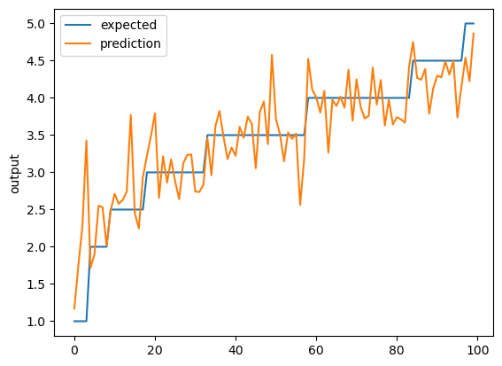

```python
from tensorflow.keras.models import Sequential
from tensorflow.keras.layers import Dense, Activation
import pandas as pd
import io
import requests
import numpy as np
from sklearn import metrics

model = Sequential()
x_train = x_train.astype('float32')
y_train = y_train.astype('float32')

model.add(Dense(25, input_dim=x_train.shape[1], activation='relu'))
model.add(Dense(10, activation='relu'))
model.add(Dense(1))

model.compile(loss='mean_squared_error', optimizer='adam')

monitor = EarlyStopping(monitor='val_loss', min_delta=1e-3, patience=5, verbose=0, mode='auto')
checkpointer = ModelCheckpoint(filepath="./dnn/best_weights.keras", verbose=0, save_best_only=True)

model.fit(x_train,y_train,validation_data=(x_test,y_test), batch_size= 128, callbacks=[monitor,checkpointer],verbose=0,epochs=1000)
model.load_weights('./dnn/best_weights.keras')

pred = model.predict(x_test)

score = np.sqrt(metrics.mean_squared_error(pred,y_test))
print("Final score (RMSE): {}".format(score))

chart_regression(pred.flatten()[0:100],y_test.to_numpy()[0:100], sort=True)
```

### Model #2

Now i will increas the hidden layer density of the first one

```
75/75 - 1s - loss: 11.5532 - val_loss: 5.6419 - 835ms/epoch - 11ms/step
75/75 - 1s - loss: 1.9672 - val_loss: 1.1514 - 537ms/epoch - 7ms/step
75/75 - 1s - loss: 0.9139 - val_loss: 0.6292 - 563ms/epoch - 8ms/step
75/75 - 1s - loss: 0.4870 - val_loss: 0.3628 - 672ms/epoch - 9ms/step
75/75 - 0s - loss: 0.3183 - val_loss: 0.2873 - 439ms/epoch - 6ms/step
75/75 - 1s - loss: 0.2561 - val_loss: 0.2502 - 660ms/epoch - 9ms/step
75/75 - 1s - loss: 0.2212 - val_loss: 0.2287 - 765ms/epoch - 10ms/step
75/75 - 0s - loss: 0.1979 - val_loss: 0.2154 - 492ms/epoch - 7ms/step
75/75 - 1s - loss: 0.1815 - val_loss: 0.2070 - 508ms/epoch - 7ms/step
75/75 - 1s - loss: 0.1693 - val_loss: 0.2016 - 529ms/epoch - 7ms/step
75/75 - 0s - loss: 0.1596 - val_loss: 0.1978 - 474ms/epoch - 6ms/step
75/75 - 1s - loss: 0.1522 - val_loss: 0.1942 - 553ms/epoch - 7ms/step
75/75 - 1s - loss: 0.1463 - val_loss: 0.1933 - 569ms/epoch - 8ms/step
75/75 - 0s - loss: 0.1408 - val_loss: 0.1928 - 464ms/epoch - 6ms/step
75/75 - 1s - loss: 0.1364 - val_loss: 0.1922 - 592ms/epoch - 8ms/step
75/75 - 0s - loss: 0.1320 - val_loss: 0.1918 - 445ms/epoch - 6ms/step
75/75 - 1s - loss: 0.1286 - val_loss: 0.1917 - 501ms/epoch - 7ms/step
75/75 - 1s - loss: 0.1246 - val_loss: 0.1945 - 530ms/epoch - 7ms/step
75/75 - 1s - loss: 0.1207 - val_loss: 0.1893 - 701ms/epoch - 9ms/step
75/75 - 0s - loss: 0.1154 - val_loss: 0.1898 - 410ms/epoch - 5ms/step
75/75 - 1s - loss: 0.1112 - val_loss: 0.1891 - 646ms/epoch - 9ms/step
75/75 - 1s - loss: 0.1067 - val_loss: 0.1865 - 559ms/epoch - 7ms/step
75/75 - 0s - loss: 0.1013 - val_loss: 0.1875 - 421ms/epoch - 6ms/step
75/75 - 1s - loss: 0.0971 - val_loss: 0.1857 - 786ms/epoch - 10ms/step
75/75 - 1s - loss: 0.0912 - val_loss: 0.1840 - 623ms/epoch - 8ms/step
75/75 - 0s - loss: 0.0857 - val_loss: 0.1866 - 442ms/epoch - 6ms/step
75/75 - 1s - loss: 0.0798 - val_loss: 0.1844 - 654ms/epoch - 9ms/step
75/75 - 0s - loss: 0.0728 - val_loss: 0.1875 - 478ms/epoch - 6ms/step
75/75 - 0s - loss: 0.0655 - val_loss: 0.1857 - 424ms/epoch - 6ms/step
75/75 - 0s - loss: 0.0580 - val_loss: 0.1864 - 476ms/epoch - 6ms/step
Epoch 30: early stopping
Final score (RMSE): 0.42893911343923247
```

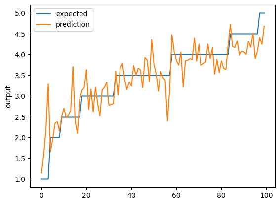

```python
from tensorflow.keras.models import Sequential
from tensorflow.keras.layers import Dense, Activation
import pandas as pd
import io
import requests
import numpy as np
from sklearn import metrics

model = Sequential()
x_train = x_train.astype('float32')
y_train = y_train.astype('float32')

model.add(Dense(100, input_dim=x_train.shape[1], activation='relu'))
model.add(Dense(10, activation='relu'))
model.add(Dense(1))

model.compile(loss='mean_squared_error', optimizer='adam')

monitor = EarlyStopping(monitor='val_loss', min_delta=1e-3, patience=5, verbose=0, mode='auto')
checkpointer = ModelCheckpoint(filepath="./dnn/best_weights.keras", verbose=0, save_best_only=True)

model.fit(x_train,y_train,validation_data=(x_test,y_test), batch_size= 128, callbacks=[monitor,checkpointer],verbose=0,epochs=1000)
model.load_weights('./dnn/best_weights.keras')

pred = model.predict(x_test)

score = np.sqrt(metrics.mean_squared_error(pred,y_test))
print("Final score (RMSE): {}".format(score))

chart_regression(pred.flatten()[0:100],y_test.to_numpy()[0:100], sort=True)
```

### Model #3

Looks like adding more density gives better out come. Now to see what happens if more hidden layer is added.

```
75/75 - 1s - loss: 4.4537 - val_loss: 0.9264 - 885ms/epoch - 12ms/step
75/75 - 1s - loss: 0.5201 - val_loss: 0.2886 - 550ms/epoch - 7ms/step
75/75 - 1s - loss: 0.2411 - val_loss: 0.2220 - 902ms/epoch - 12ms/step
75/75 - 1s - loss: 0.1866 - val_loss: 0.2022 - 720ms/epoch - 10ms/step
75/75 - 0s - loss: 0.1628 - val_loss: 0.1935 - 453ms/epoch - 6ms/step
75/75 - 1s - loss: 0.1491 - val_loss: 0.1911 - 716ms/epoch - 10ms/step
75/75 - 1s - loss: 0.1410 - val_loss: 0.1925 - 686ms/epoch - 9ms/step
75/75 - 1s - loss: 0.1344 - val_loss: 0.1907 - 649ms/epoch - 9ms/step
75/75 - 1s - loss: 0.1286 - val_loss: 0.1933 - 600ms/epoch - 8ms/step
75/75 - 1s - loss: 0.1228 - val_loss: 0.1931 - 568ms/epoch - 8ms/step
75/75 - 1s - loss: 0.1167 - val_loss: 0.1914 - 602ms/epoch - 8ms/step
Epoch 11: early stopping
Final score (RMSE): 0.436655680417307
```

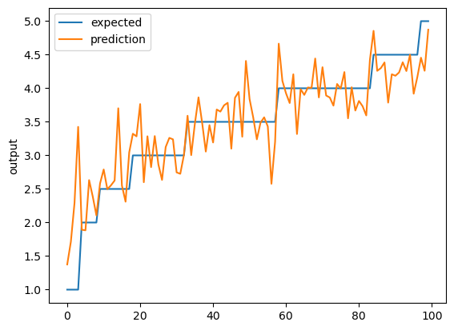

```python
from tensorflow.keras.models import Sequential
from tensorflow.keras.layers import Dense, Activation
import pandas as pd
import io
import requests
import numpy as np
from sklearn import metrics

model = Sequential()
x_train = x_train.astype('float32')
y_train = y_train.astype('float32')

model.add(Dense(100, input_dim=x_train.shape[1], activation='relu'))
model.add(Dense(50, activation='relu'))
model.add(Dense(10, activation='relu'))
model.add(Dense(1))

model.compile(loss='mean_squared_error', optimizer='adam')

monitor = EarlyStopping(monitor='val_loss', min_delta=1e-3, patience=5, verbose=0, mode='auto')
checkpointer = ModelCheckpoint(filepath="./dnn/best_weights.keras", verbose=0, save_best_only=True)

model.fit(x_train,y_train,validation_data=(x_test,y_test), batch_size= 128, callbacks=[monitor,checkpointer],verbose=0,epochs=1000)
model.load_weights('./dnn/best_weights.keras')

pred = model.predict(x_test)

score = np.sqrt(metrics.mean_squared_error(pred,y_test))
print("Final score (RMSE): {}".format(score))

chart_regression(pred.flatten()[0:100],y_test.to_numpy()[0:100], sort=True)
```

### Model #4

Another one.

```
75/75 - 1s - loss: 4.1630 - val_loss: 0.7570 - 1s/epoch - 15ms/step
75/75 - 0s - loss: 0.4389 - val_loss: 0.2683 - 259ms/epoch - 3ms/step
75/75 - 0s - loss: 0.2209 - val_loss: 0.2106 - 343ms/epoch - 5ms/step
75/75 - 0s - loss: 0.1733 - val_loss: 0.1998 - 441ms/epoch - 6ms/step
75/75 - 0s - loss: 0.1520 - val_loss: 0.1991 - 419ms/epoch - 6ms/step
75/75 - 0s - loss: 0.1416 - val_loss: 0.1947 - 478ms/epoch - 6ms/step
75/75 - 1s - loss: 0.1275 - val_loss: 0.1959 - 547ms/epoch - 7ms/step
75/75 - 0s - loss: 0.1180 - val_loss: 0.1946 - 341ms/epoch - 5ms/step
75/75 - 0s - loss: 0.1090 - val_loss: 0.1956 - 407ms/epoch - 5ms/step
75/75 - 1s - loss: 0.0998 - val_loss: 0.1972 - 591ms/epoch - 8ms/step
75/75 - 0s - loss: 0.0916 - val_loss: 0.1969 - 447ms/epoch - 6ms/step
Epoch 11: early stopping
Final score (RMSE): 0.44112378213684317
```

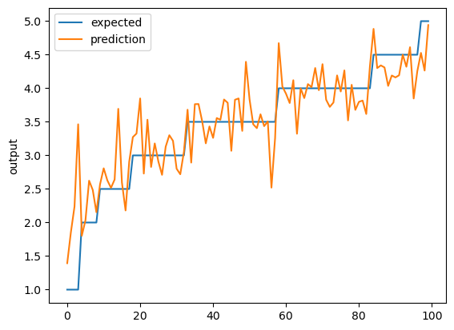

```python
from tensorflow.keras.models import Sequential
from tensorflow.keras.layers import Dense, Activation
import pandas as pd
import io
import requests
import numpy as np
from sklearn import metrics

model = Sequential()
x_train = x_train.astype('float32')
y_train = y_train.astype('float32')

model.add(Dense(100, input_dim=x_train.shape[1], activation='relu'))
model.add(Dense(65, activation='relu'))
model.add(Dense(35, activation='relu'))
model.add(Dense(12, activation='relu'))
model.add(Dense(1))

model.compile(loss='mean_squared_error', optimizer='adam')

monitor = EarlyStopping(monitor='val_loss', min_delta=1e-3, patience=5, verbose=0, mode='auto')
checkpointer = ModelCheckpoint(filepath="./dnn/best_weights.keras", verbose=0, save_best_only=True)

model.fit(x_train,y_train,validation_data=(x_test,y_test), batch_size= 128, callbacks=[monitor,checkpointer],verbose=0,epochs=1000)
model.load_weights('./dnn/best_weights.keras')

pred = model.predict(x_test)

score = np.sqrt(metrics.mean_squared_error(pred,y_test))
print("Final score (RMSE): {}".format(score))

chart_regression(pred.flatten()[0:100],y_test.to_numpy()[0:100], sort=True)
```

### Model #5

```
75/75 - 1s - loss: 1.8785 - val_loss: 0.6839 - 652ms/epoch - 9ms/step
75/75 - 0s - loss: 0.6504 - val_loss: 0.6347 - 364ms/epoch - 5ms/step
75/75 - 0s - loss: 0.5816 - val_loss: 0.5476 - 440ms/epoch - 6ms/step
75/75 - 0s - loss: 0.4696 - val_loss: 0.4210 - 283ms/epoch - 4ms/step
75/75 - 1s - loss: 0.3449 - val_loss: 0.3139 - 685ms/epoch - 9ms/step
75/75 - 0s - loss: 0.2710 - val_loss: 0.2731 - 427ms/epoch - 6ms/step
75/75 - 0s - loss: 0.2428 - val_loss: 0.2590 - 415ms/epoch - 6ms/step
75/75 - 0s - loss: 0.2277 - val_loss: 0.2404 - 406ms/epoch - 5ms/step
75/75 - 1s - loss: 0.2155 - val_loss: 0.2344 - 604ms/epoch - 8ms/step
75/75 - 0s - loss: 0.2098 - val_loss: 0.2280 - 368ms/epoch - 5ms/step
75/75 - 0s - loss: 0.2030 - val_loss: 0.2273 - 415ms/epoch - 6ms/step
75/75 - 0s - loss: 0.1986 - val_loss: 0.2188 - 395ms/epoch - 5ms/step
75/75 - 0s - loss: 0.1956 - val_loss: 0.2130 - 301ms/epoch - 4ms/step
75/75 - 0s - loss: 0.1913 - val_loss: 0.2096 - 449ms/epoch - 6ms/step
75/75 - 1s - loss: 0.1877 - val_loss: 0.2068 - 529ms/epoch - 7ms/step
75/75 - 1s - loss: 0.1826 - val_loss: 0.2111 - 506ms/epoch - 7ms/step
75/75 - 0s - loss: 0.1822 - val_loss: 0.2040 - 479ms/epoch - 6ms/step
75/75 - 1s - loss: 0.1777 - val_loss: 0.2138 - 530ms/epoch - 7ms/step
75/75 - 0s - loss: 0.1768 - val_loss: 0.2059 - 383ms/epoch - 5ms/step
75/75 - 1s - loss: 0.1794 - val_loss: 0.2000 - 557ms/epoch - 7ms/step
75/75 - 0s - loss: 0.1732 - val_loss: 0.1967 - 337ms/epoch - 4ms/step
75/75 - 0s - loss: 0.1747 - val_loss: 0.1953 - 419ms/epoch - 6ms/step
75/75 - 0s - loss: 0.1733 - val_loss: 0.1956 - 436ms/epoch - 6ms/step
75/75 - 0s - loss: 0.1691 - val_loss: 0.2109 - 462ms/epoch - 6ms/step
75/75 - 0s - loss: 0.1667 - val_loss: 0.2029 - 437ms/epoch - 6ms/step
75/75 - 0s - loss: 0.1643 - val_loss: 0.2080 - 282ms/epoch - 4ms/step
75/75 - 1s - loss: 0.1643 - val_loss: 0.1968 - 544ms/epoch - 7ms/step
Epoch 27: early stopping
Final score (RMSE): 0.44187693853796534
```

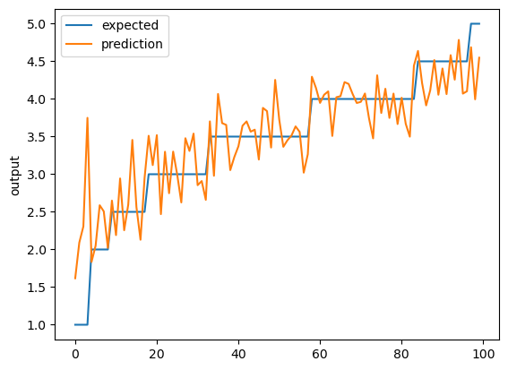

```python
from tensorflow.keras.models import Sequential
from tensorflow.keras.layers import Dense, Activation
import pandas as pd
import io
import requests
import numpy as np
from sklearn import metrics

model = Sequential()
x_train = x_train.astype('float32')
y_train = y_train.astype('float32')

model.add(Dense(100, input_dim=x_train.shape[1], activation='relu'))
model.add(Dense(65, activation='relu'))
model.add(Dense(35, activation='relu'))
model.add(Dense(12, activation='relu'))
model.add(Dense(1))

model.compile(loss='mean_squared_error', optimizer='sgd')

monitor = EarlyStopping(monitor='val_loss', min_delta=1e-3, patience=5, verbose=0, mode='auto')
checkpointer = ModelCheckpoint(filepath="./dnn/best_weights.keras", verbose=0, save_best_only=True)

model.fit(x_train,y_train,validation_data=(x_test,y_test), batch_size= 128, callbacks=[monitor,checkpointer],verbose=0,epochs=1000)
model.load_weights('./dnn/best_weights.keras')

pred = model.predict(x_test)

score = np.sqrt(metrics.mean_squared_error(pred,y_test))
print("Final score (RMSE): {}".format(score))

chart_regression(pred.flatten()[0:100],y_test.to_numpy()[0:100], sort=True)
```

### Model #6

```
75/75 - 1s - loss: 1.1831 - val_loss: 0.6868 - 742ms/epoch - 10ms/step
75/75 - 0s - loss: 0.5698 - val_loss: 0.3269 - 490ms/epoch - 7ms/step
75/75 - 0s - loss: 0.2360 - val_loss: 0.2220 - 435ms/epoch - 6ms/step
75/75 - 0s - loss: 0.1965 - val_loss: 0.2011 - 488ms/epoch - 7ms/step
75/75 - 0s - loss: 0.1756 - val_loss: 0.2042 - 354ms/epoch - 5ms/step
75/75 - 1s - loss: 0.1655 - val_loss: 0.1930 - 623ms/epoch - 8ms/step
75/75 - 0s - loss: 0.1624 - val_loss: 0.1834 - 447ms/epoch - 6ms/step
75/75 - 0s - loss: 0.1559 - val_loss: 0.2188 - 382ms/epoch - 5ms/step
75/75 - 1s - loss: 0.1544 - val_loss: 0.1819 - 528ms/epoch - 7ms/step
75/75 - 0s - loss: 0.1474 - val_loss: 0.2151 - 354ms/epoch - 5ms/step
75/75 - 0s - loss: 0.1427 - val_loss: 0.1914 - 326ms/epoch - 4ms/step
75/75 - 0s - loss: 0.1397 - val_loss: 0.1786 - 335ms/epoch - 4ms/step
75/75 - 1s - loss: 0.1382 - val_loss: 0.1795 - 589ms/epoch - 8ms/step
75/75 - 0s - loss: 0.1337 - val_loss: 0.1844 - 389ms/epoch - 5ms/step
75/75 - 0s - loss: 0.1320 - val_loss: 0.1732 - 411ms/epoch - 5ms/step
75/75 - 0s - loss: 0.1297 - val_loss: 0.1741 - 296ms/epoch - 4ms/step
75/75 - 1s - loss: 0.1307 - val_loss: 0.1820 - 566ms/epoch - 8ms/step
75/75 - 0s - loss: 0.1289 - val_loss: 0.1850 - 315ms/epoch - 4ms/step
75/75 - 0s - loss: 0.1224 - val_loss: 0.1702 - 459ms/epoch - 6ms/step
75/75 - 0s - loss: 0.1236 - val_loss: 0.1882 - 276ms/epoch - 4ms/step
75/75 - 0s - loss: 0.1180 - val_loss: 0.1716 - 460ms/epoch - 6ms/step
75/75 - 1s - loss: 0.1184 - val_loss: 0.1745 - 549ms/epoch - 7ms/step
75/75 - 0s - loss: 0.1118 - val_loss: 0.1726 - 375ms/epoch - 5ms/step
75/75 - 0s - loss: 0.1111 - val_loss: 0.1893 - 362ms/epoch - 5ms/step
Epoch 24: early stopping
Final score (RMSE): 0.4125631357782705
```

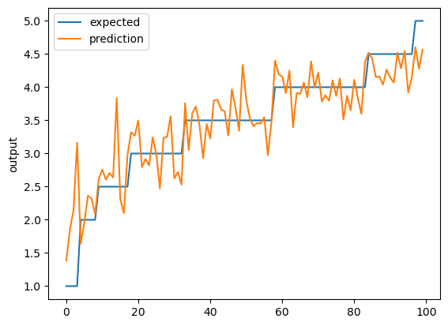

```python
from tensorflow.keras.models import Sequential
from tensorflow.keras.layers import Dense, Activation
from tensorflow.keras import optimizers
import pandas as pd
import io
import requests
import numpy as np
from sklearn import metrics

model = Sequential()
x_train = x_train.astype('float32')
y_train = y_train.astype('float32')

model.add(Dense(100, input_dim=x_train.shape[1], activation='relu'))
model.add(Dense(65, activation='relu'))
model.add(Dense(35, activation='relu'))
model.add(Dense(12, activation='relu'))
model.add(Dense(1))

sgd = optimizers.SGD(learning_rate=0.01, decay=1e-6, momentum=0.9, nesterov=True)

model.compile(loss='mean_squared_error', optimizer=sgd)

monitor = EarlyStopping(monitor='val_loss', min_delta=1e-3, patience=5, verbose=0, mode='auto')
checkpointer = ModelCheckpoint(filepath="./dnn/best_weights.keras", verbose=0, save_best_only=True)

model.fit(x_train,y_train,validation_data=(x_test,y_test), batch_size= 128, callbacks=[monitor,checkpointer],verbose=0,epochs=1000)
model.load_weights('./dnn/best_weights.keras')

pred = model.predict(x_test)

score = np.sqrt(metrics.mean_squared_error(pred,y_test))
print("Final score (RMSE): {}".format(score))

chart_regression(pred.flatten()[0:100],y_test.to_numpy()[0:100], sort=True)
```

### Model #7

Increasing the learning rate

```
75/75 - 1s - loss: 0.9950 - val_loss: 0.6703 - 721ms/epoch - 10ms/step
75/75 - 1s - loss: 0.6360 - val_loss: 0.5192 - 625ms/epoch - 8ms/step
75/75 - 1s - loss: 0.2639 - val_loss: 0.2104 - 512ms/epoch - 7ms/step
75/75 - 0s - loss: 0.1966 - val_loss: 0.1930 - 478ms/epoch - 6ms/step
75/75 - 1s - loss: 0.1778 - val_loss: 0.1857 - 631ms/epoch - 8ms/step
75/75 - 1s - loss: 0.1735 - val_loss: 0.1794 - 747ms/epoch - 10ms/step
75/75 - 1s - loss: 0.1626 - val_loss: 0.1869 - 536ms/epoch - 7ms/step
75/75 - 1s - loss: 0.1557 - val_loss: 0.1788 - 632ms/epoch - 8ms/step
75/75 - 0s - loss: 0.1464 - val_loss: 0.1710 - 463ms/epoch - 6ms/step
75/75 - 1s - loss: 0.1447 - val_loss: 0.1850 - 567ms/epoch - 8ms/step
75/75 - 1s - loss: 0.1353 - val_loss: 0.1721 - 520ms/epoch - 7ms/step
75/75 - 1s - loss: 0.1328 - val_loss: 0.1698 - 588ms/epoch - 8ms/step
75/75 - 1s - loss: 0.1336 - val_loss: 0.1711 - 569ms/epoch - 8ms/step
75/75 - 0s - loss: 0.1281 - val_loss: 0.2281 - 345ms/epoch - 5ms/step
75/75 - 1s - loss: 0.1259 - val_loss: 0.1675 - 662ms/epoch - 9ms/step
75/75 - 0s - loss: 0.1285 - val_loss: 0.1766 - 407ms/epoch - 5ms/step
75/75 - 0s - loss: 0.1227 - val_loss: 0.1676 - 466ms/epoch - 6ms/step
75/75 - 0s - loss: 0.1139 - val_loss: 0.1678 - 415ms/epoch - 6ms/step
75/75 - 0s - loss: 0.1107 - val_loss: 0.1683 - 480ms/epoch - 6ms/step
75/75 - 0s - loss: 0.1107 - val_loss: 0.1689 - 415ms/epoch - 6ms/step
Epoch 20: early stopping
Final score (RMSE): 0.4092313770805606
```

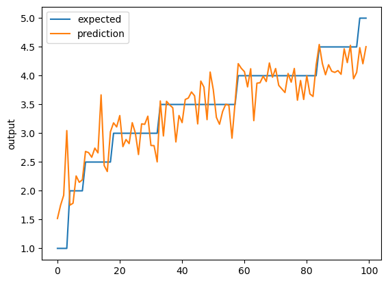

```python
from tensorflow.keras.models import Sequential
from tensorflow.keras.layers import Dense, Activation
from tensorflow.keras import optimizers
import pandas as pd
import io
import requests
import numpy as np
from sklearn import metrics

model = Sequential()
x_train = x_train.astype('float32')
y_train = y_train.astype('float32')

model.add(Dense(100, input_dim=x_train.shape[1], activation='relu'))
model.add(Dense(65, activation='relu'))
model.add(Dense(35, activation='relu'))
model.add(Dense(12, activation='relu'))
model.add(Dense(1))

sgd = optimizers.SGD(learning_rate=0.03, decay=1e-6, momentum=0.9, nesterov=True)

model.compile(loss='mean_squared_error', optimizer=sgd)

monitor = EarlyStopping(monitor='val_loss', min_delta=1e-3, patience=5, verbose=0, mode='auto')
checkpointer = ModelCheckpoint(filepath="./dnn/best_weights.keras", verbose=0, save_best_only=True)

model.fit(x_train,y_train,validation_data=(x_test,y_test), batch_size= 128, callbacks=[monitor,checkpointer],verbose=0,epochs=1000)
model.load_weights('./dnn/best_weights.keras')

pred = model.predict(x_test)

score = np.sqrt(metrics.mean_squared_error(pred,y_test))
print("Final score (RMSE): {}".format(score))

chart_regression(pred.flatten()[0:100],y_test.to_numpy()[0:100], sort=True)
```

### Model #8

decreasing the learning rate

```
75/75 - 1s - loss: 1.6295 - val_loss: 0.7113 - 939ms/epoch - 13ms/step
75/75 - 1s - loss: 0.6888 - val_loss: 0.7022 - 531ms/epoch - 7ms/step
75/75 - 1s - loss: 0.6833 - val_loss: 0.6911 - 560ms/epoch - 7ms/step
75/75 - 0s - loss: 0.6549 - val_loss: 0.6279 - 467ms/epoch - 6ms/step
75/75 - 1s - loss: 0.4270 - val_loss: 0.2862 - 553ms/epoch - 7ms/step
75/75 - 1s - loss: 0.2163 - val_loss: 0.2183 - 688ms/epoch - 9ms/step
75/75 - 1s - loss: 0.1859 - val_loss: 0.2197 - 524ms/epoch - 7ms/step
75/75 - 0s - loss: 0.1715 - val_loss: 0.1935 - 467ms/epoch - 6ms/step
75/75 - 1s - loss: 0.1632 - val_loss: 0.1891 - 556ms/epoch - 7ms/step
75/75 - 0s - loss: 0.1558 - val_loss: 0.1879 - 378ms/epoch - 5ms/step
75/75 - 0s - loss: 0.1531 - val_loss: 0.1919 - 457ms/epoch - 6ms/step
75/75 - 1s - loss: 0.1503 - val_loss: 0.2152 - 898ms/epoch - 12ms/step
75/75 - 1s - loss: 0.1441 - val_loss: 0.1899 - 526ms/epoch - 7ms/step
75/75 - 0s - loss: 0.1408 - val_loss: 0.1792 - 336ms/epoch - 4ms/step
75/75 - 1s - loss: 0.1391 - val_loss: 0.1789 - 525ms/epoch - 7ms/step
75/75 - 0s - loss: 0.1349 - val_loss: 0.1755 - 411ms/epoch - 5ms/step
75/75 - 1s - loss: 0.1328 - val_loss: 0.1754 - 562ms/epoch - 7ms/step
75/75 - 1s - loss: 0.1281 - val_loss: 0.2018 - 724ms/epoch - 10ms/step
75/75 - 1s - loss: 0.1285 - val_loss: 0.1799 - 712ms/epoch - 9ms/step
75/75 - 1s - loss: 0.1261 - val_loss: 0.1801 - 663ms/epoch - 9ms/step
75/75 - 0s - loss: 0.1231 - val_loss: 0.1737 - 491ms/epoch - 7ms/step
75/75 - 0s - loss: 0.1211 - val_loss: 0.1730 - 396ms/epoch - 5ms/step
75/75 - 1s - loss: 0.1166 - val_loss: 0.2186 - 601ms/epoch - 8ms/step
75/75 - 1s - loss: 0.1184 - val_loss: 0.2367 - 679ms/epoch - 9ms/step
75/75 - 0s - loss: 0.1175 - val_loss: 0.1772 - 419ms/epoch - 6ms/step
75/75 - 1s - loss: 0.1138 - val_loss: 0.2023 - 639ms/epoch - 9ms/step
Epoch 26: early stopping
Final score (RMSE): 0.415951482830117
```

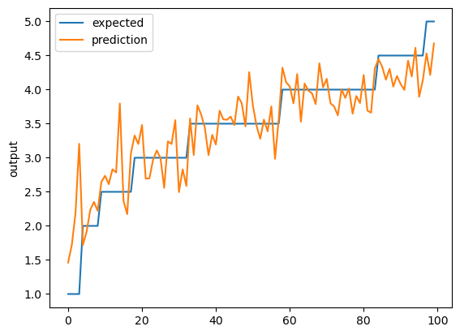

```python
from tensorflow.keras.models import Sequential
from tensorflow.keras.layers import Dense, Activation
from tensorflow.keras import optimizers
import pandas as pd
import io
import requests
import numpy as np
from sklearn import metrics

model = Sequential()
x_train = x_train.astype('float32')
y_train = y_train.astype('float32')

model.add(Dense(100, input_dim=x_train.shape[1], activation='relu'))
model.add(Dense(65, activation='relu'))
model.add(Dense(35, activation='relu'))
model.add(Dense(12, activation='relu'))
model.add(Dense(1))

sgd = optimizers.SGD(learning_rate=0.008, decay=1e-6, momentum=0.9, nesterov=True)

model.compile(loss='mean_squared_error', optimizer=sgd)

monitor = EarlyStopping(monitor='val_loss', min_delta=1e-3, patience=5, verbose=0, mode='auto')
checkpointer = ModelCheckpoint(filepath="./dnn/best_weights.keras", verbose=0, save_best_only=True)

model.fit(x_train,y_train,validation_data=(x_test,y_test), batch_size= 128, callbacks=[monitor,checkpointer],verbose=0,epochs=1000)
model.load_weights('./dnn/best_weights.keras')

pred = model.predict(x_test)

score = np.sqrt(metrics.mean_squared_error(pred,y_test))
print("Final score (RMSE): {}".format(score))

chart_regression(pred.flatten()[0:100],y_test.to_numpy()[0:100], sort=True)
```

### Model #9

```
75/75 - 1s - loss: 1.3047 - val_loss: 0.6935 - 901ms/epoch - 12ms/step
75/75 - 1s - loss: 0.6595 - val_loss: 0.6250 - 608ms/epoch - 8ms/step
75/75 - 1s - loss: 0.3991 - val_loss: 0.2362 - 528ms/epoch - 7ms/step
75/75 - 1s - loss: 0.2023 - val_loss: 0.2031 - 531ms/epoch - 7ms/step
75/75 - 1s - loss: 0.1771 - val_loss: 0.1921 - 543ms/epoch - 7ms/step
75/75 - 1s - loss: 0.1709 - val_loss: 0.1971 - 522ms/epoch - 7ms/step
75/75 - 1s - loss: 0.1588 - val_loss: 0.1833 - 517ms/epoch - 7ms/step
75/75 - 1s - loss: 0.1549 - val_loss: 0.2194 - 577ms/epoch - 8ms/step
75/75 - 0s - loss: 0.1528 - val_loss: 0.1769 - 404ms/epoch - 5ms/step
75/75 - 1s - loss: 0.1482 - val_loss: 0.1779 - 566ms/epoch - 8ms/step
75/75 - 1s - loss: 0.1429 - val_loss: 0.1757 - 556ms/epoch - 7ms/step
75/75 - 1s - loss: 0.1433 - val_loss: 0.1740 - 520ms/epoch - 7ms/step
75/75 - 1s - loss: 0.1378 - val_loss: 0.3281 - 608ms/epoch - 8ms/step
75/75 - 1s - loss: 0.1415 - val_loss: 0.1793 - 751ms/epoch - 10ms/step
75/75 - 0s - loss: 0.1343 - val_loss: 0.1790 - 462ms/epoch - 6ms/step
75/75 - 0s - loss: 0.1309 - val_loss: 0.1719 - 452ms/epoch - 6ms/step
75/75 - 0s - loss: 0.1266 - val_loss: 0.1727 - 467ms/epoch - 6ms/step
75/75 - 0s - loss: 0.1286 - val_loss: 0.1721 - 261ms/epoch - 3ms/step
75/75 - 0s - loss: 0.1223 - val_loss: 0.1726 - 360ms/epoch - 5ms/step
75/75 - 1s - loss: 0.1212 - val_loss: 0.1755 - 655ms/epoch - 9ms/step
75/75 - 1s - loss: 0.1189 - val_loss: 0.1723 - 507ms/epoch - 7ms/step
Epoch 21: early stopping
Final score (RMSE): 0.41460617355155743
```

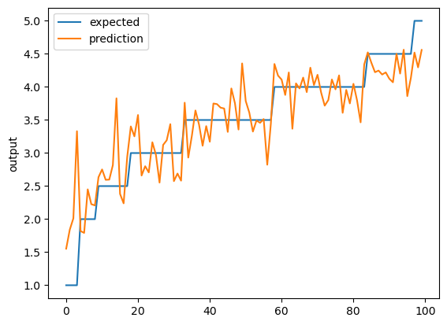

```python
from tensorflow.keras.models import Sequential
from tensorflow.keras.layers import Dense, Activation
from tensorflow.keras import optimizers
import pandas as pd
import io
import requests
import numpy as np
from sklearn import metrics

model = Sequential()
x_train = x_train.astype('float32')
y_train = y_train.astype('float32')

model.add(Dense(100, input_dim=x_train.shape[1], activation='relu'))
model.add(Dense(65, activation='relu'))
model.add(Dense(35, activation='relu'))
model.add(Dense(12, activation='relu'))
model.add(Dense(1))

sgd = optimizers.SGD(learning_rate=0.01, decay=3e-6, momentum=0.9, nesterov=True)

model.compile(loss='mean_squared_error', optimizer=sgd)

monitor = EarlyStopping(monitor='val_loss', min_delta=1e-3, patience=5, verbose=0, mode='auto')
checkpointer = ModelCheckpoint(filepath="./dnn/best_weights.keras", verbose=0, save_best_only=True)

model.fit(x_train,y_train,validation_data=(x_test,y_test), batch_size= 128, callbacks=[monitor,checkpointer],verbose=0,epochs=1000)
model.load_weights('./dnn/best_weights.keras')

pred = model.predict(x_test)

score = np.sqrt(metrics.mean_squared_error(pred,y_test))
print("Final score (RMSE): {}".format(score))

chart_regression(pred.flatten()[0:100],y_test.to_numpy()[0:100], sort=True)
```

### Model #10

decreaseing the decay

```
75/75 - 1s - loss: 1.2273 - val_loss: 0.6991 - 1s/epoch - 16ms/step
75/75 - 1s - loss: 0.6771 - val_loss: 0.6804 - 652ms/epoch - 9ms/step
75/75 - 0s - loss: 0.5390 - val_loss: 0.2942 - 426ms/epoch - 6ms/step
75/75 - 1s - loss: 0.2235 - val_loss: 0.2083 - 789ms/epoch - 11ms/step
75/75 - 1s - loss: 0.1909 - val_loss: 0.2114 - 609ms/epoch - 8ms/step
75/75 - 1s - loss: 0.1738 - val_loss: 0.1882 - 556ms/epoch - 7ms/step
75/75 - 1s - loss: 0.1655 - val_loss: 0.1884 - 694ms/epoch - 9ms/step
75/75 - 1s - loss: 0.1584 - val_loss: 0.2073 - 561ms/epoch - 7ms/step
75/75 - 1s - loss: 0.1534 - val_loss: 0.1801 - 582ms/epoch - 8ms/step
75/75 - 1s - loss: 0.1505 - val_loss: 0.1829 - 610ms/epoch - 8ms/step
75/75 - 1s - loss: 0.1499 - val_loss: 0.1783 - 694ms/epoch - 9ms/step
75/75 - 1s - loss: 0.1460 - val_loss: 0.2155 - 696ms/epoch - 9ms/step
75/75 - 1s - loss: 0.1423 - val_loss: 0.1757 - 663ms/epoch - 9ms/step
75/75 - 1s - loss: 0.1386 - val_loss: 0.1986 - 683ms/epoch - 9ms/step
75/75 - 1s - loss: 0.1377 - val_loss: 0.1837 - 666ms/epoch - 9ms/step
75/75 - 1s - loss: 0.1331 - val_loss: 0.1784 - 655ms/epoch - 9ms/step
75/75 - 1s - loss: 0.1330 - val_loss: 0.1724 - 601ms/epoch - 8ms/step
75/75 - 1s - loss: 0.1312 - val_loss: 0.1868 - 528ms/epoch - 7ms/step
75/75 - 1s - loss: 0.1295 - val_loss: 0.1819 - 641ms/epoch - 9ms/step
75/75 - 1s - loss: 0.1243 - val_loss: 0.1775 - 751ms/epoch - 10ms/step
75/75 - 1s - loss: 0.1216 - val_loss: 0.1745 - 679ms/epoch - 9ms/step
75/75 - 0s - loss: 0.1221 - val_loss: 0.1712 - 482ms/epoch - 6ms/step
75/75 - 1s - loss: 0.1170 - val_loss: 0.1889 - 796ms/epoch - 11ms/step
75/75 - 1s - loss: 0.1160 - val_loss: 0.1701 - 618ms/epoch - 8ms/step
75/75 - 1s - loss: 0.1154 - val_loss: 0.1815 - 526ms/epoch - 7ms/step
75/75 - 1s - loss: 0.1140 - val_loss: 0.1710 - 560ms/epoch - 7ms/step
75/75 - 1s - loss: 0.1051 - val_loss: 0.2056 - 534ms/epoch - 7ms/step
75/75 - 1s - loss: 0.1113 - val_loss: 0.1764 - 507ms/epoch - 7ms/step
75/75 - 1s - loss: 0.1033 - val_loss: 0.1694 - 668ms/epoch - 9ms/step
Epoch 29: early stopping
Final score (RMSE): 0.41163500463222985
```

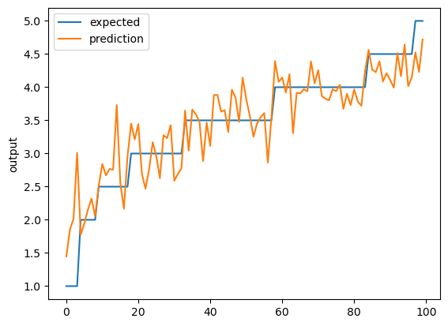

```python
from tensorflow.keras.models import Sequential
from tensorflow.keras.layers import Dense, Activation
from tensorflow.keras import optimizers
import pandas as pd
import io
import requests
import numpy as np
from sklearn import metrics

model = Sequential()
x_train = x_train.astype('float32')
y_train = y_train.astype('float32')

model.add(Dense(100, input_dim=x_train.shape[1], activation='relu'))
model.add(Dense(65, activation='relu'))
model.add(Dense(35, activation='relu'))
model.add(Dense(12, activation='relu'))
model.add(Dense(1))

sgd = optimizers.SGD(learning_rate=0.01, decay=8e-7, momentum=0.9, nesterov=True)

model.compile(loss='mean_squared_error', optimizer=sgd)

monitor = EarlyStopping(monitor='val_loss', min_delta=1e-3, patience=5, verbose=0, mode='auto')
checkpointer = ModelCheckpoint(filepath="./dnn/best_weights.keras", verbose=0, save_best_only=True)

model.fit(x_train,y_train,validation_data=(x_test,y_test), batch_size= 128, callbacks=[monitor,checkpointer],verbose=0,epochs=1000)
model.load_weights('./dnn/best_weights.keras')

pred = model.predict(x_test)

score = np.sqrt(metrics.mean_squared_error(pred,y_test))
print("Final score (RMSE): {}".format(score))

chart_regression(pred.flatten()[0:100],y_test.to_numpy()[0:100], sort=True)
```